# Práctica 6

Carlos Mota Romero

2023-03-27

## Ejercicio 1: Instalación de paquetes

Para instalar diversas librerías que necesitaremos para trabajar en el siguiente ejercicio, usaremos el comando `install.packages` y para activarlos lo haremos con el comando `library`

```r
install.packages("MASS", repos = "http://cran.us.r-project.org")
library(MASS)
install.packages("caret", repos = "http://cran.us.r-project.org")
library(caret)
installed.packages("stats", repos = "http://cran.us.r-project.org")
```

```
##      Package LibPath Version Priority Depends Imports LinkingTo Suggests
##      Enhances License License_is_FOSS License_restricts_use OS_type Archs
##      MD5sum NeedsCompilation Built
```

```r
library(stats)
install.packages("olsrr", repos = "http://cran.us.r-project.org")
library(olsrr)
install.packages("kableExtra", repos = "http://cran.us.r-project.org")
library(kableExtra)
install.packages("knitr", repos = "http://cran.us.r-project.org")
library(knitr)
install.packages("rmarkdown", repos = "http://cran.us.r-project.org")
library(rmarkdown)
```

## Ejercicio 2: Crear vectores

Creamos vectores con `c`y dotándolos de un nombre

```r
y_cuentas <- c(110,2,6,98,40,94,31,5,8,10)
y_cuentas
```

```
##  [1] 110   2   6  98  40  94  31   5   8  10
```

```r
x_distancias <- c(1.1,100.2,90.3,5.4,57.5,6.6,34.7,65.8,57.9,86.1)
x_distancias
```

```
##  [1]   1.1 100.2  90.3   5.4  57.5   6.6  34.7  65.8  57.9  86.1
```

## Ejercicio 3: Comprobar la linealidad

Comprobamos la linealidad de forma matemática con los comandos `cor`y `cor.test`El primero nos da un valor que nos informa sobre la correlacion de las variables, y el segundo nos aporta este mismo dato con un p-value que nos informa sobre las posibilidades de que ese valor no se deba al azar.

```r
cor(x_distancias, y_cuentas)
```

```
## [1] -0.9249824
```

```r
cor.test(x_distancias, y_cuentas)
```

```
##
##  Pearson's product-moment correlation
##
## data:  x_distancias and y_cuentas
## t = -6.8847, df = 8, p-value = 0.0001265
## alternative hypothesis: true correlation is not equal to 0
## 95 percent confidence interval:
##  -0.9824414 -0.7072588
## sample estimates:
##        cor
## -0.9249824
```

Con esto podemos llegar a saber que mantienen una correlación inversa, es decir que a más alejado del punto 0 menos cuentas aparecen. También podemos saber que es una correlación fiable porque el p-value es menor a 0.05 que es lo mínimo teniendo una confianza del 95%.

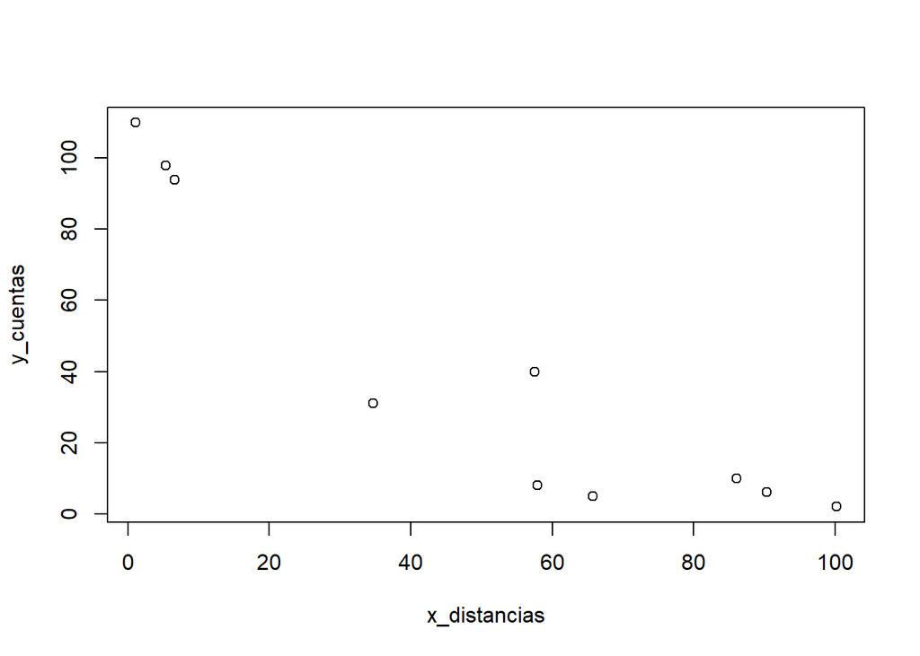

```r
plot(x_distancias, y_cuentas)
```

Al generar en un gráfico estas dos variables podemos ver que se mantienen gráficamente lo que habíamos asumido matemáticamente.

## Ejercicio 4: Comprobar la normalidad:

Para comprobar la normalidad de la variable explicativa (en este caso el vector `x_distancias`) podemos hacer un histograma (con la función `hist`y añadiendo una linea de densidad con `lines(density(x))`para comprobar la distribución de los valores. Si tuviera una distribución en forma de campana, sería una variable normal, como no es así, comprobamos que la variable explicativa no tenga una distribución normal de los datos.

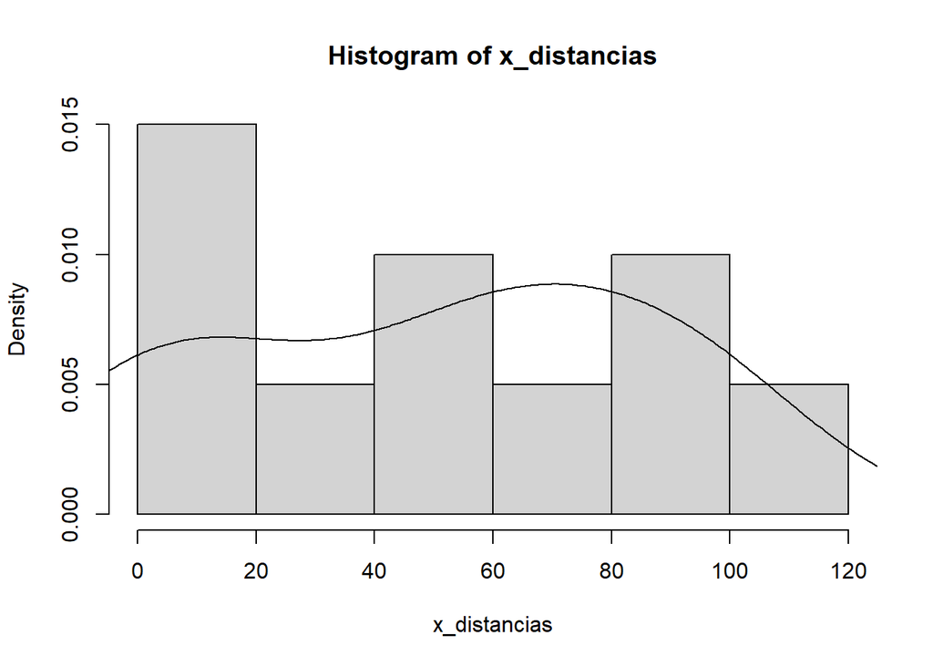

```r
hist(x_distancias, prob=TRUE)
lines(density(x_distancias))
```

Para comprobar matemáticamente y de forma automática si la distribución de datos de una variable es normal, podemos usar la función `shapiro.test`. Pero al tener tan pocos valores en nuestra variable, esta función no nos da un resultado fiable. De hecho en este caso, nos da un valor p mayor a 0’05, lo que indicaría una distribución normal de los datos, cuando sabemos que esto no es el caso para nuestra muestra.

```r
shapiro.test(x_distancias)
```

```
##
##  Shapiro-Wilk normality test
##
## data:  x_distancias
## W = 0.90687, p-value = 0.2602
```

## Ejercicio 5: Multiplicar las variables

Para multiplicar las variables utilizamos el caracter `*` y llamamos al objeto creado con un nuevo nombre con el símbolo `<-`.

```r
xy <- x_distancias*y_cuentas
xy
```

```
##  [1]  121.0  200.4  541.8  529.2 2300.0  620.4 1075.7  329.0  463.2  861.0
```

```r
x_cuadrado <- x_distancias^2
x_cuadrado
```

```
##  [1]     1.21 10040.04  8154.09    29.16  3306.25    43.56  1204.09  4329.64
##  [9]  3352.41  7413.21
```

## Ejercicio 7: Crear un dataframe

Para crear un dataframe con todos los vectores que hemos estado creando hasta ahora, usamos la función `data.frame`.

```r
tabla_datos <- data.frame(y_cuentas, x_distancias, xy, x_cuadrado)
tabla_datos
```

```
##    y_cuentas x_distancias     xy x_cuadrado
## 1        110          1.1  121.0       1.21
## 2          2        100.2  200.4   10040.04
## 3          6         90.3  541.8    8154.09
## 4         98          5.4  529.2      29.16
## 5         40         57.5 2300.0    3306.25
## 6         94          6.6  620.4      43.56
## 7         31         34.7 1075.7    1204.09
## 8          5         65.8  329.0    4329.64
## 9          8         57.9  463.2    3352.41
## 10        10         86.1  861.0    7413.21
```

## Ejercicio 8: Visualizar tabla con kableExtra

Para poder visualizar una tabla de datos previamente creada con la librería de `kableExtra`primero tenemos que estilizarla y luego ejecutarla; algo que podemos conseguir con los siguientes comandos:

```r
kbl(tabla_datos) %>%
  kable_minimal()
```

| y_cuentas | x_distancias | xy | x_cuadrado |
| --- | --- | --- | --- |
| 110 | 1.1 | 121.0 | 1.21 |
| 2 | 100.2 | 200.4 | 10040.04 |
| 6 | 90.3 | 541.8 | 8154.09 |
| 98 | 5.4 | 529.2 | 29.16 |
| 40 | 57.5 | 2300.0 | 3306.25 |
| 94 | 6.6 | 620.4 | 43.56 |
| 31 | 34.7 | 1075.7 | 1204.09 |
| 5 | 65.8 | 329.0 | 4329.64 |
| 8 | 57.9 | 463.2 | 3352.41 |
| 10 | 86.1 | 861.0 | 7413.21 |

## Ejercicio 9: Sumatorios

Para realizar sumatorios corremos la función `sum`, dándole a cada valor que necesitemos un nuevo nombre. Para ello le damos a la función la columna de nuestro dataframe de la que queremos que realice un sumatorio con el símbolo `$`.

```r
sum_y <- sum(tabla_datos$y_cuentas)
sum_y
```

```
## [1] 404
```

```r
sum_x <- sum(tabla_datos$x_distancias)
sum_x
```

```
## [1] 505.6
```

```r
sum_xy <- sum(tabla_datos$xy)
sum_xy
```

```
## [1] 7041.7
```

```r
sum_x2 <- sum(tabla_datos$x_cuadrado)
sum_x2
```

```
## [1] 37873.66
```

## Ejercicio 10: Añadir los sumatorios al dataframe

Para añadir los valores obtenidos de los sumatorios de cada columna utilizaremos la función `rbind` que lo que hace es añadir nuevos datos a un dataframe ya creado; como argumentos le damos nuestra tabla y un nuevo vector que hemos creado previamente que almacena todos los valores que queremos añadir, en el mismo orden de las columnas de nuestro dataframe. Luego le he cambiado el nombre a la fila donde se almacenan los sumatorios para distinguirla del resto de casos con la función `rownames`.

```r
sumatorios <- c(sum_y, sum_x, sum_xy, sum_x2)
tabla_datos2 <- rbind(tabla_datos, sumatorios)
tabla_datos2
```

```
##    y_cuentas x_distancias     xy x_cuadrado
## 1        110          1.1  121.0       1.21
## 2          2        100.2  200.4   10040.04
## 3          6         90.3  541.8    8154.09
## 4         98          5.4  529.2      29.16
## 5         40         57.5 2300.0    3306.25
## 6         94          6.6  620.4      43.56
## 7         31         34.7 1075.7    1204.09
## 8          5         65.8  329.0    4329.64
## 9          8         57.9  463.2    3352.41
## 10        10         86.1  861.0    7413.21
## 11       404        505.6 7041.7   37873.66
```

```r
rownames(tabla_datos2)[11] <- "sumatorio"
rownames(tabla_datos2)[11]
```

```
## [1] "sumatorio"
```

## Ejercicio 11:

Para calcular los datos necesarios para crear nuestra recta de regresión utilizaremos la función `lm`, le daremos un nombre al objeto creado, y luego con la función `summary`extraeremos los datos que necesitamos para la recta de regresión.

```r
datos <- data.frame(x_distancias, y_cuentas)
modelo <- lm(y_cuentas ~ x_distancias, datos)
summary(modelo)
```

```
##
## Call:
## lm(formula = y_cuentas ~ x_distancias, data = datos)
##
## Residuals:
##     Min      1Q  Median      3Q     Max
## -26.644 -12.672   7.693   8.730  15.825
##
## Coefficients:
##              Estimate Std. Error t value Pr(>|t|)
## (Intercept)   95.3710     9.7188   9.813 9.77e-06 ***
## x_distancias  -1.0872     0.1579  -6.885 0.000126 ***
## ---
## Signif. codes:  0 '***' 0.001 '**' 0.01 '*' 0.05 '.' 0.1 ' ' 1
##
## Residual standard error: 17.52 on 8 degrees of freedom
## Multiple R-squared:  0.8556, Adjusted R-squared:  0.8375
## F-statistic:  47.4 on 1 and 8 DF,  p-value: 0.0001265
```

## Ejercicio 12: Graficar la recta de regresión:

Primero necesitamos crear nuestra gráfico de nube de puntos, lo cual haremos con la función `plot` dándole nuestros ejes x e y. Luego graficaremos la recta de regresión con la función `abline` que la creará a partir de los datos del modelo creado en el anterior ejercicio. Con los argumentos `main`, `xlab`e `ylab` le damos un nombre al gráfico y editamos las etiquetas asociadas al eje x e y, respectivamente.

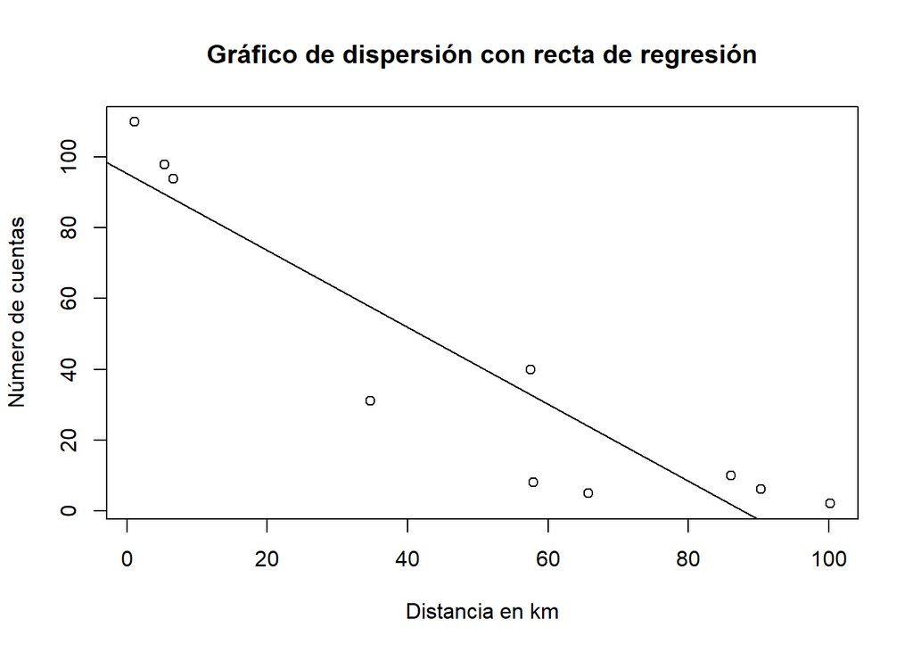

```r
plot(x_distancias, y_cuentas, main="Gráfico de dispersión con recta de regresión", xlab= "Distancia en km", ylab= "Número de cuentas")
abline(modelo)
```

## Ejercicio 13: Residuos

Llamamos residuos a la diferencia que existe entre los valores del eje Y y los que predecimos a través de una recta de regresión. Estos valores los podemos calcular con la función `resid`. Los residuos estandarizados se calculan con el valor de un residuo dividido entre una estimación de su desviación estándar. Lo podemos hacer de forma automática con la función `rstandard`. Por último los residuos estudentizados se calculan con el valor residual de regresión dividido por su error estándar ajustado. Lo podemos hacer con la función: `rstudent`.

```r
resid(modelo)
```

```
##          1          2          3          4          5          6          7
##  15.824925  15.570779   8.807066   8.500073   7.145471   5.804766 -26.643686
##          8          9         10
## -18.830406 -24.419631   8.240642
```

```r
rstandard(modelo)
```

```
##          1          2          3          4          5          6          7
##  1.0784816  1.0622593  0.5721649  0.5661008  0.4307982  0.3843280 -1.6213545
##          8          9         10
## -1.1448722 -1.4726329  0.5266739
```

```r
rstudent(modelo)
```

```
##          1          2          3          4          5          6          7
##  1.0912716  1.0721374  0.5465101  0.5404749  0.4077319  0.3628715 -1.8509341
##          8          9         10
## -1.1711614 -1.6134626  0.5014281
```

## Ejercicio 14: Predecir a través del modelo de regresión un valor de X

Para ello sustituimos el valor de x que queremos calcular en nuestra recta de regresión:

```r
y_6.6 <- 95.36 - 1.082 * 6.6
y_6.6
```

```
## [1] 88.2188
```

## Ejercicio 15: Generar dos conjuntos de datos:

Queremos generar dos conjuntos de datos, uno para entrenar y crear una recta de regresión y otro para comprobar la validez de esta.

```r
library(dplyr)
data <- data.frame(x_distancias, y_cuentas)
train <- data %>% dplyr::sample_frac(.8)
test <- dplyr::anti_join(data, train)
train
```

```
##   x_distancias y_cuentas
## 1         86.1        10
## 2         65.8         5
## 3         90.3         6
## 4        100.2         2
## 5         34.7        31
## 6         57.9         8
## 7         57.5        40
## 8          6.6        94
```

```r
test
```

```
##   x_distancias y_cuentas
## 1          1.1       110
## 2          5.4        98
```

## Ejercicio 16: Generar el modelo otra vez

```r
modelo_train <- lm(x_distancias ~ y_cuentas, train)
summary(modelo_train)
```

```
##
## Call:
## lm(formula = x_distancias ~ y_cuentas, data = train)
##
## Residuals:
##     Min      1Q  Median      3Q     Max
## -22.128 -14.599   6.012  11.506  18.569
##
## Coefficients:
##             Estimate Std. Error t value Pr(>|t|)
## (Intercept)  83.3419     7.7995   10.69 3.96e-05 ***
## y_cuentas    -0.8553     0.2046   -4.18  0.00581 **
## ---
## Signif. codes:  0 '***' 0.001 '**' 0.01 '*' 0.05 '.' 0.1 ' ' 1
##
## Residual standard error: 16.9 on 6 degrees of freedom
## Multiple R-squared:  0.7444, Adjusted R-squared:  0.7018
## F-statistic: 17.48 on 1 and 6 DF,  p-value: 0.005811
```

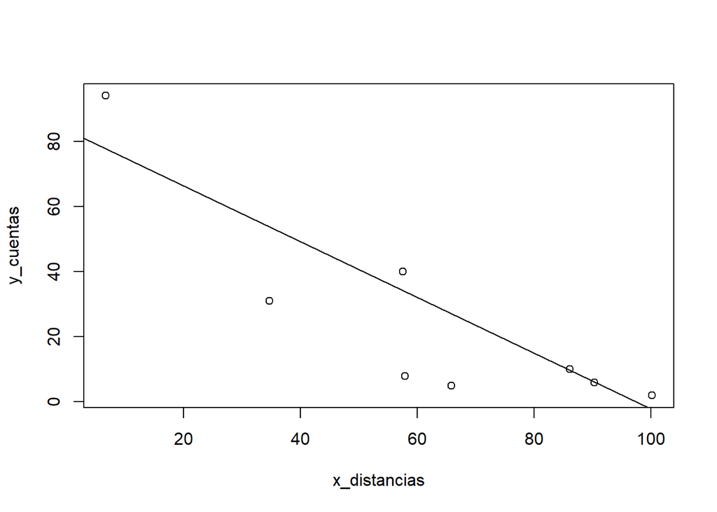

```r
plot(train)
abline(modelo_train)
```

## Ejercicio 17: Asteriscos y R^2

Los asteriscos que aparecen en la columna de la derecha de los datos obtenidos con la función `summary` de nuestro modelo, nos informan sobre la fiabilidad de nuestro modelo. A más asteriscos menor es la posibilidad de que la relación que hemos generado entre las variables se deba al azar. R^2 nos informa sobre la relación porcentual que existe entre los datos y la línea de regresión que hemos creado. A más se acerque R^2 al 1 más se acercan los datos de la variable dependiente a nuestra línea de regresión.

## Ejercicio 18: Grados de libertad

Los grados de libertad del modelo son la cantidad de datos que se utilizan para estimar los parámetros de un modelo concreto. En el caso de los modelos de regresión lineal como el que hemos creado, los parámetros a estimar son la pendiente y la intersección con el eje Y. Los grados de libertad del modelo se calculan restando el número de parámetros a estimar a las observaciones del modelo. En nuestro caso tenemos dos parámetros a estimar y varias observaciones. Si usamos el primer modelo que hemos creado, sería 10 el número de observaciones menos 2, el número de parámetros a estimar, lo cual nos daría 8. Si cogemos el segundo modelo creado (entrenamiento), el resultado sería de 6 porque el número de observaciones es menor. El grado de libertad de un modelo es relevante porque nos informa sobre la fiabilidad del modelo. A mayor grado de libertad, más fiable será el modelo, porque tenemos más observaciones. Siendo este el caso, nuestro modelo original sería más fiable siguiendo este pensamiento; pero ya que hemos incluido todos nuestros datos para crearlo, no tendríamos oportunidad de comprobar su fiabilidad con otro conjunto de datos mediante un método de validación.

## Ejercicio 19: Varianza

La varianza de un modelo nos informa sobre cómo de correcto es el ajuste que se ha producido entre la variable dependiente y la independiente, y con ello comprobar la significancia estadística de nuestra variable dependiente. En un modelo de regresión lineal, la varianza total de la variable dependiente (y) se puede descomponer en dos componentes: la varianza explicada por el modelo (también conocida como suma de cuadrados de regresión) y la varianza no explicada por el modelo (también conocida como suma de cuadrados de residuos). Para poder usar el código posterior es necesario que nuestros valores estén almacenados en un dataframe; para ello:

```r
train_df <- data.frame(train)
train_df
```

```
##   x_distancias y_cuentas
## 1         86.1        10
## 2         65.8         5
## 3         90.3         6
## 4        100.2         2
## 5         34.7        31
## 6         57.9         8
## 7         57.5        40
## 8          6.6        94
```

```r
is.data.frame(train_df)
```

```
## [1] TRUE
```

Sabiendo que nuestros datos sí están almacenados ahora en un dataframe, podemos utilizar el siguiente código para calcular la varianza de nuestro modelo:

```r
anova(modelo_train)
```

```
## Analysis of Variance Table
##
## Response: x_distancias
##           Df Sum Sq Mean Sq F value   Pr(>F)
## y_cuentas  1 4991.8  4991.8  17.476 0.005811 **
## Residuals  6 1713.9   285.6
## ---
## Signif. codes:  0 '***' 0.001 '**' 0.01 '*' 0.05 '.' 0.1 ' ' 1
```

```r
var_total <- var(train_df$y)
var_total
```

```
## [1] 974.8571
```

```r
var_explicada <- sum((modelo_train$fitted.values - mean(train_df$y))^2)
var_explicada
```

```
## [1] 16475.52
```

```r
var_no_explicada <- sum((train_df$y - modelo_train$fitted.values)^2)
var_no_explicada
```

```
## [1] 34972.42
```

## Ejercicio 20: Validación del modelo

El error cuadrático medio es una métrica utilizada para evaluar el rendimiento de un modelo de regresión lineal mediante una operación de validación cruzada. Representa la media de los errores cuadráticos entre las predicciones del modelo y los valores reales en los datos de prueba. Un valor más bajo indica que el modelo es mejor para ajustarse a los datos. Podemos calcularlo con el siguiente código:

```r
predicciones <- predict(modelo_train, newdata = test)
predicciones
```

```
##           1           2
## -10.7391816  -0.4757877
```

```r
error_cuadratico_medio <- sqrt(mean((test$y - predicciones)^2))
error_cuadratico_medio
```

```
## [1] 110.1713
```

## Ejercicio 21: Valores influyentes

Para comprobar si existen valores influyentes en nuestro modelo podemos usar el método de Cook, que mide la influencia de una observación en el ajuste del modelo, eliminando la observación y comparando el ajuste del modelo con y sin ella. Si el ajuste del modelo cambia significativamente, entonces la observación se considera influyente. Para ello corremos el siguiente código:

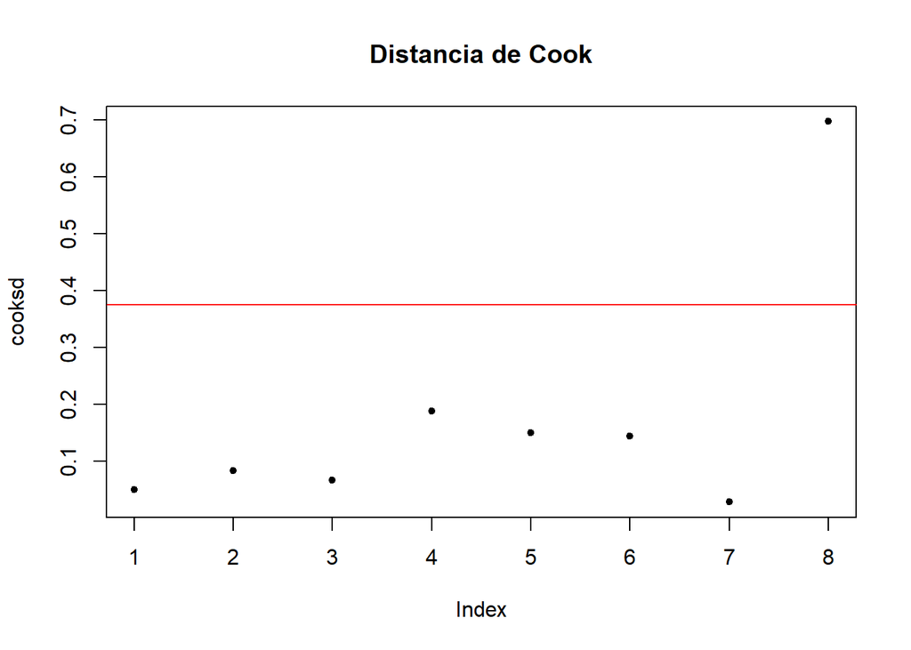

```r
cooksd <- cooks.distance(modelo_train)
plot(cooksd, pch = 20, main = "Distancia de Cook")
abline(h = 3/length(cooksd), col = "red")
```

## Ejercicio 22: Supuesto de independencia de los residuos

El supuesto de independencia de los residuos en un modelo de regresión lineal es una suposición que hacemos al asumir que los residuos no deben mostrar patrones o tendencias en su distribución y por tanto que no están correlacionados entre sí. Si esto no se cumple, no podemos decir que los errores sean independientes y por ello que las estimaciones que obtenemos pueden estar sesgadas. Para comprobar dicho supuesto podemos hacer lo siguiente:

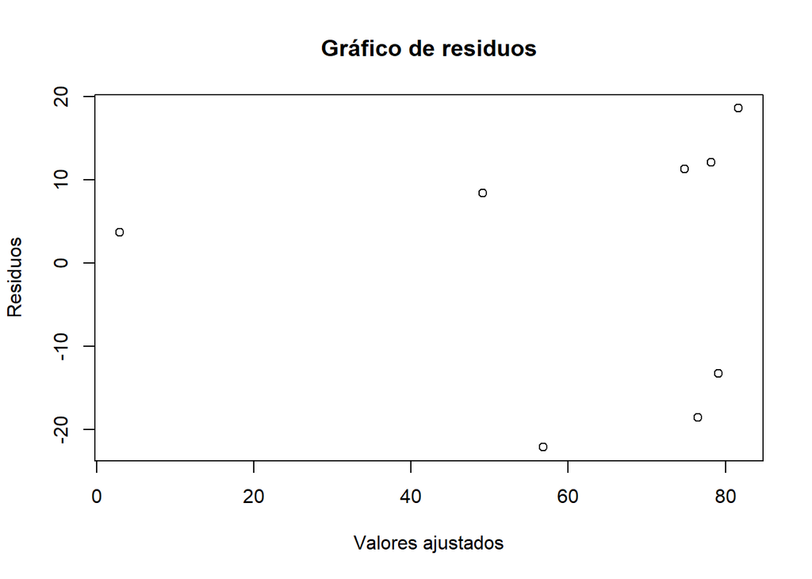

```r
residuos_train <- resid(modelo_train)
plot(modelo_train$fitted.values, residuos_train, xlab = "Valores ajustados", ylab = "Residuos", main = "Gráfico de residuos")
```

Al graficar los resultados comprobamos que sí existe una tendencia de agrupación entre los residuos, pero que no todos ellos se encuentran igualados, teniendo un caso concreto en el que esta tendencia desaparece. Es muy probable que tengamos que ajustar nuestros datos del modelo, para generar otro con mejores capacidades predictivas.

## Ejercicio 23: Comprobar rango de errores

La primera forma en la que podemos comprobar si el rango de errores para nuestro modelo es constante sería con la gráfica del anterior ejercicio, que como hemos hablado tiene un outlier, y por tanto no podemos decir que permanezcan constantes. Otra forma de hacerlo sería usando el método/test de Breusch-Pagan:

```r
library(lmtest)
bp <- bptest(modelo_train)
bp
```

```
##
##  studentized Breusch-Pagan test
##
## data:  modelo_train
## BP = 1.6759, df = 1, p-value = 0.1955
```